# KNN

Erick Marroquín

## Paquetes

```r
library(caret)      # KNN, preprocesamiento, evaluación
library(ggplot2)    # Visualizaciones
library(dplyr)      # Manipulación de datos
library(tidyr)      # Transformación de datos
```

## Datos

Se utiliza el dataset **German Credit** (UCI Machine Learning Repository / Kaggle).

Contiene información de **1,000 clientes** de un banco alemán. El objetivo es predecir si un cliente representa un **buen o mal riesgo crediticio**.

```r
data("GermanCredit", package = "caret")

# Vista general
glimpse(GermanCredit)
```

```
## Rows: 1,000
## Columns: 62
## $ Duration                               <int> 6, 48, 12, 42, 24, 36, 24, 36, …
## $ Amount                                 <int> 1169, 5951, 2096, 7882, 4870, 9…
## $ InstallmentRatePercentage              <int> 4, 2, 2, 2, 3, 2, 3, 2, 2, 4, 3…
## $ ResidenceDuration                      <int> 4, 2, 3, 4, 4, 4, 4, 2, 4, 2, 1…
## $ Age                                    <int> 67, 22, 49, 45, 53, 35, 53, 35,…
## $ NumberExistingCredits                  <int> 2, 1, 1, 1, 2, 1, 1, 1, 1, 2, 1…
## $ NumberPeopleMaintenance                <int> 1, 1, 2, 2, 2, 2, 1, 1, 1, 1, 1…
## $ Telephone                              <dbl> 0, 1, 1, 1, 1, 0, 1, 0, 1, 1, 1…
## $ ForeignWorker                          <dbl> 1, 1, 1, 1, 1, 1, 1, 1, 1, 1, 1…
## $ Class                                  <fct> Good, Bad, Good, Good, Bad, Goo…
## $ CheckingAccountStatus.lt.0             <dbl> 1, 0, 0, 1, 1, 0, 0, 0, 0, 0, 0…
## $ CheckingAccountStatus.0.to.200         <dbl> 0, 1, 0, 0, 0, 0, 0, 1, 0, 1, 1…
## $ CheckingAccountStatus.gt.200           <dbl> 0, 0, 0, 0, 0, 0, 0, 0, 0, 0, 0…
```

[output cut: 49 more lines]

### Variables de interés

Para mantener el ejemplo claro y visualizable, se trabaja con un subconjunto de variables:

| Variable | Descripción |
| --- | --- |
| `Age` | Edad del cliente (años) |
| `Amount` | Monto de crédito solicitado (DM) |
| `Duration` | Duración del crédito (meses) |
| `Class` | Buen o mal pagador (`Good` / `Bad`) |

```r
datos <- GermanCredit %>%
  select(Age, Amount, Duration, Class) %>%
  mutate(Class = factor(Class, levels = c("Good", "Bad")))

# Distribución de clases
table(datos$Class)
```

```
##
## Good  Bad
##  700  300
```

## Exploración

### Distribución por clase

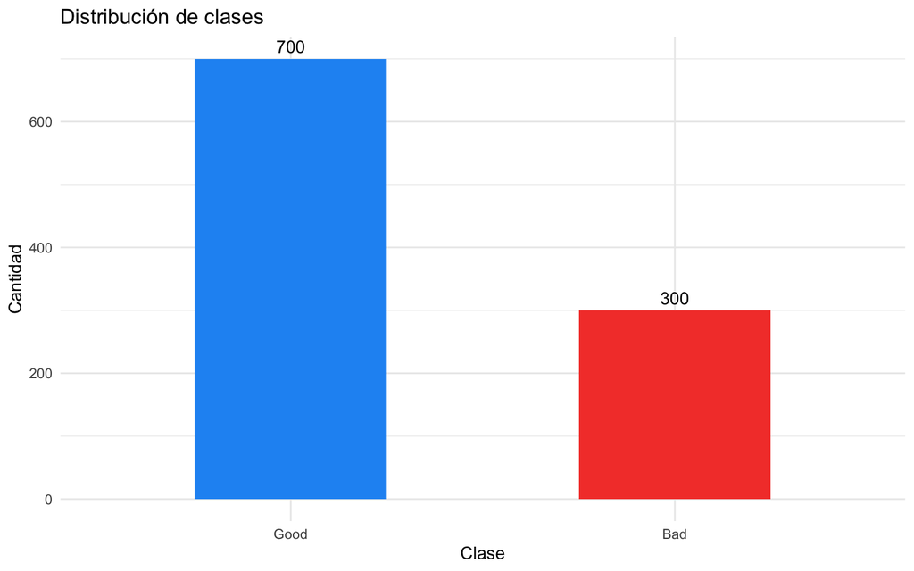

```r
datos %>%
  count(Class) %>%
  ggplot(aes(x = Class, y = n, fill = Class)) +
  geom_col(width = 0.5) +
  geom_text(aes(label = n), vjust = -0.5) +
  scale_fill_manual(values = c("Good" = "#2196F3", "Bad" = "#F44336")) +
  labs(title = "Distribución de clases", x = "Clase", y = "Cantidad") +
  theme_minimal() +
  theme(legend.position = "none")
```

> El dataset está **desbalanceado**: hay más clientes buenos que malos. Esto se toma en cuenta al interpretar las métricas.

### Edad vs Monto por clase

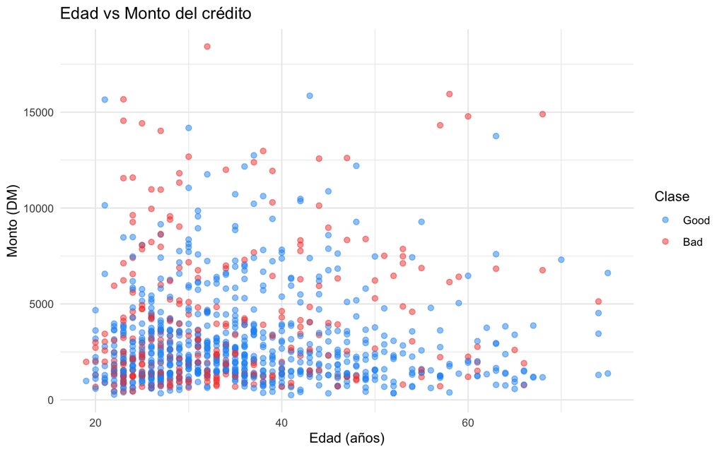

```r
ggplot(datos, aes(x = Age, y = Amount, color = Class)) +
  geom_point(alpha = 0.5, size = 1.8) +
  scale_color_manual(values = c("Good" = "#2196F3", "Bad" = "#F44336")) +
  labs(
    title = "Edad vs Monto del crédito",
    x = "Edad (años)",
    y = "Monto (DM)",
    color = "Clase"
  ) +
  theme_minimal()
```

### Duración vs Monto por clase

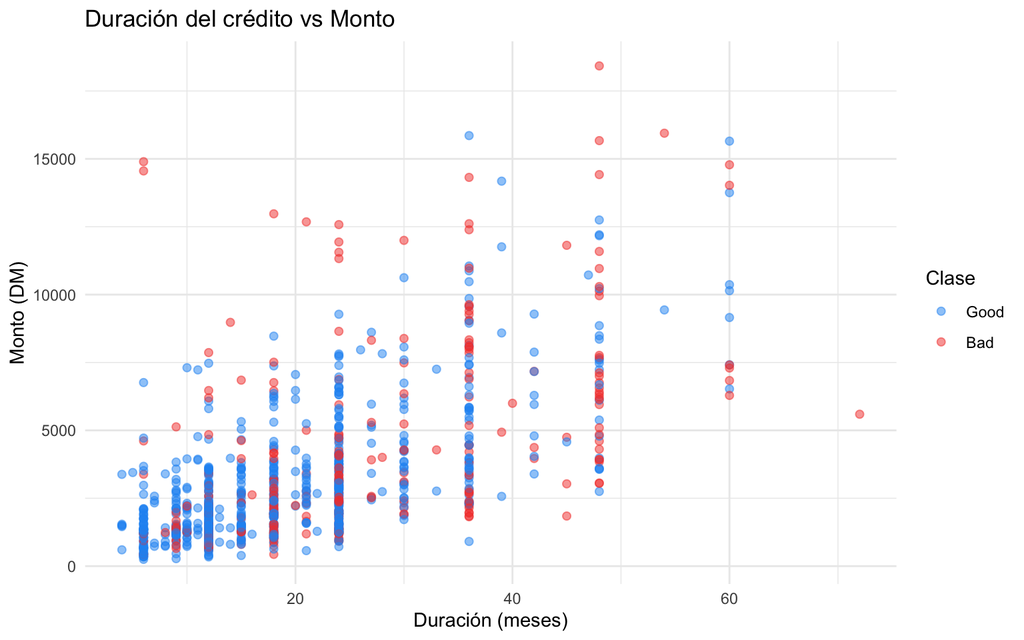

```r
ggplot(datos, aes(x = Duration, y = Amount, color = Class)) +
  geom_point(alpha = 0.5, size = 1.8) +
  scale_color_manual(values = c("Good" = "#2196F3", "Bad" = "#F44336")) +
  labs(
    title = "Duración del crédito vs Monto",
    x = "Duración (meses)",
    y = "Monto (DM)",
    color = "Clase"
  ) +
  theme_minimal()
```

## Preprocesamiento

### ¿Por qué es necesario escalar?

Las variables tienen rangos muy distintos:

```r
datos %>%
  select(-Class) %>%
  summarise(across(everything(), list(min = min, max = max, media = mean))) %>%
  pivot_longer(everything(), names_to = c("variable", "stat"), names_sep = "_") %>%
  pivot_wider(names_from = stat, values_from = value)
```

```
## # A tibble: 3 × 4
##   variable   min   max  media
##   <chr>    <dbl> <dbl>  <dbl>
## 1 Age         19    75   35.5
## 2 Amount     250 18424 3271.
## 3 Duration     4    72   20.9
```

Sin escalado, `Amount` (valores hasta 18,424) dominaría el cálculo de distancia frente a `Age` (valores entre 19 y 75).

### Normalización Min-Max

Se transforma cada variable al rango [0, 1]:

```r
preproc <- preProcess(
  datos %>% select(-Class),
  method = "range"
)

datos_escalados <- predict(preproc, datos %>% select(-Class))
datos_escalados$Class <- datos$Class

# Verificar el rango resultante
summary(datos_escalados %>% select(-Class))
```

```
##       Age             Amount           Duration
##  Min.   :0.0000   Min.   :0.00000   Min.   :0.0000
##  1st Qu.:0.1429   1st Qu.:0.06138   1st Qu.:0.1176
##  Median :0.2500   Median :0.11387   Median :0.2059
##  Mean   :0.2955   Mean   :0.16624   Mean   :0.2486
##  3rd Qu.:0.4107   3rd Qu.:0.20481   3rd Qu.:0.2941
##  Max.   :1.0000   Max.   :1.00000   Max.   :1.0000
```

## División Train / Test

Se separa el 70% de los datos para entrenamiento y el 30% para prueba. La partición se hace de forma **estratificada** para preservar la proporción de clases.

```r
set.seed(42)

indice <- createDataPartition(datos_escalados$Class, p = 0.7, list = FALSE)

entrenamiento <- datos_escalados[indice, ]
prueba        <- datos_escalados[-indice, ]

cat("Entrenamiento:", nrow(entrenamiento), "instancias\n")
```

```
## Entrenamiento: 700 instancias
```

```r
cat("Prueba:       ", nrow(prueba), "instancias\n")
```

```
## Prueba:        300 instancias
```

```r
# Verificar que la proporción se preservó
prop.table(table(entrenamiento$Class))
```

```
##
## Good  Bad
##  0.7  0.3
```

```r
prop.table(table(prueba$Class))
```

```
##
## Good  Bad
##  0.7  0.3
```

## Construcción del Modelo

### Modelo inicial con K = 5

```r
set.seed(42)

control <- trainControl(method = "none")

modelo_k5 <- train(
  Class ~ .,
  data      = entrenamiento,
  method    = "knn",
  trControl = control,
  tuneGrid  = data.frame(k = 5)
)

modelo_k5
```

```
## k-Nearest Neighbors
##
## 700 samples
##   3 predictor
##   2 classes: 'Good', 'Bad'
##
## No pre-processing
## Resampling: None
```

### Predicción en datos de prueba

```r
predicciones <- predict(modelo_k5, newdata = prueba)

head(data.frame(
  Real      = prueba$Class,
  Predicho  = predicciones
), 10)
```

```
##    Real Predicho
## 1  Good     Good
## 2   Bad     Good
## 3  Good     Good
## 4  Good     Good
## 5  Good     Good
## 6  Good     Good
## 7   Bad     Good
## 8  Good     Good
## 9  Good      Bad
## 10 Good     Good
```

## Evaluación

### Matriz de Confusión

```r
conf_mat <- confusionMatrix(
  data      = predicciones,
  reference = prueba$Class,
  positive  = "Bad"
)

conf_mat
```

```
## Confusion Matrix and Statistics
##
##           Reference
## Prediction Good Bad
##       Good  182  67
##       Bad    28  23
##
##                Accuracy : 0.6833
##                  95% CI : (0.6274, 0.7356)
##     No Information Rate : 0.7
##     P-Value [Acc > NIR] : 0.7572
##
##                   Kappa : 0.1395
##
##  Mcnemar's Test P-Value : 9.67e-05
##
##             Sensitivity : 0.25556
##             Specificity : 0.86667
##          Pos Pred Value : 0.45098
##          Neg Pred Value : 0.73092
##              Prevalence : 0.30000
##          Detection Rate : 0.07667
##    Detection Prevalence : 0.17000
##       Balanced Accuracy : 0.56111
##
##        'Positive' Class : Bad
##
```

### Interpretación de métricas

```r
metricas <- data.frame(
  Métrica   = c("Exactitud", "Precisión", "Recall (Sensibilidad)", "F1-Score", "Especificidad"),
  Valor     = c(
    conf_mat$overall["Accuracy"],
    conf_mat$byClass["Precision"],
    conf_mat$byClass["Sensitivity"],
    conf_mat$byClass["F1"],
    conf_mat$byClass["Specificity"]
  )
)

metricas$Valor <- round(metricas$Valor, 3)
metricas
```

```
##                           Métrica Valor
## Accuracy                Exactitud 0.683
## Precision               Precisión 0.451
## Sensitivity Recall (Sensibilidad) 0.256
## F1                       F1-Score 0.326
## Specificity         Especificidad 0.867
```

> **Nota:** Con datos desbalanceados, la exactitud puede ser alta aunque el modelo no detecte bien la clase minoritaria (`Bad`). Se presta atención especial al **Recall** para la clase `Bad`.

## Efecto de K

Se entrena el modelo con distintos valores de K para observar cómo cambia el desempeño.

```r
set.seed(42)

valores_k <- seq(1, 31, by = 2)  # Solo impares

resultados_k <- lapply(valores_k, function(k) {
  mod <- train(
    Class ~ .,
    data      = entrenamiento,
    method    = "knn",
    trControl = trainControl(method = "cv", number = 5),
    tuneGrid  = data.frame(k = k)
  )
  data.frame(
    k         = k,
    Exactitud = max(mod$results$Accuracy)
  )
})

resultados_k <- bind_rows(resultados_k)
resultados_k
```

```
##     k Exactitud
## 1   1 0.5957143
## 2   3 0.6357143
## 3   5 0.6685714
## 4   7 0.6885714
## 5   9 0.6742857
## 6  11 0.7014286
## 7  13 0.6985714
## 8  15 0.7028571
## 9  17 0.7000000
## 10 19 0.7028571
## 11 21 0.7128571
## 12 23 0.7100000
## 13 25 0.6985714
## 14 27 0.7100000
## 15 29 0.7071429
## 16 31 0.7100000
```

### Visualización del efecto de K

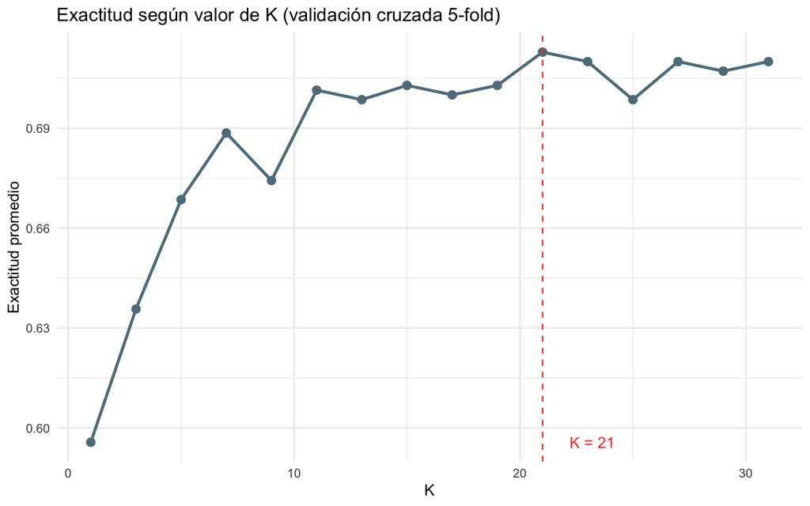

```r
mejor_k <- resultados_k$k[which.max(resultados_k$Exactitud)]

ggplot(resultados_k, aes(x = k, y = Exactitud)) +
  geom_line(color = "#607D8B", linewidth = 1) +
  geom_point(size = 2.5, color = "#607D8B") +
  geom_vline(xintercept = mejor_k, linetype = "dashed", color = "#F44336") +
  annotate("text", x = mejor_k + 1.2, y = min(resultados_k$Exactitud),
           label = paste("K =", mejor_k), color = "#F44336", hjust = 0) +
  labs(
    title = "Exactitud según valor de K (validación cruzada 5-fold)",
    x = "K",
    y = "Exactitud promedio"
  ) +
  theme_minimal()
```

## Modelo Final con el Mejor K

```r
set.seed(42)

modelo_final <- train(
  Class ~ .,
  data      = entrenamiento,
  method    = "knn",
  trControl = trainControl(method = "none"),
  tuneGrid  = data.frame(k = mejor_k)
)

predicciones_final <- predict(modelo_final, newdata = prueba)

conf_final <- confusionMatrix(
  data      = predicciones_final,
  reference = prueba$Class,
  positive  = "Bad"
)

conf_final
```

```
## Confusion Matrix and Statistics
##
##           Reference
## Prediction Good Bad
##       Good  199  78
##       Bad    11  12
##
##                Accuracy : 0.7033
##                  95% CI : (0.6481, 0.7545)
##     No Information Rate : 0.7
##     P-Value [Acc > NIR] : 0.4782
##
##                   Kappa : 0.1028
##
##  Mcnemar's Test P-Value : 2.634e-12
##
##             Sensitivity : 0.13333
##             Specificity : 0.94762
##          Pos Pred Value : 0.52174
##          Neg Pred Value : 0.71841
##              Prevalence : 0.30000
##          Detection Rate : 0.04000
##    Detection Prevalence : 0.07667
##       Balanced Accuracy : 0.54048
##
##        'Positive' Class : Bad
##
```

### Comparación K = 5 vs mejor K

```r
data.frame(
  Modelo      = c(paste("K =", 5), paste("K =", mejor_k)),
  Exactitud   = c(
    round(conf_mat$overall["Accuracy"], 3),
    round(conf_final$overall["Accuracy"], 3)
  ),
  Recall_Bad  = c(
    round(conf_mat$byClass["Sensitivity"], 3),
    round(conf_final$byClass["Sensitivity"], 3)
  ),
  F1_Bad      = c(
    round(conf_mat$byClass["F1"], 3),
    round(conf_final$byClass["F1"], 3)
  )
)
```

```
##   Modelo Exactitud Recall_Bad F1_Bad
## 1  K = 5     0.683      0.256  0.326
## 2 K = 21     0.703      0.133  0.212
```

## Predicción sobre un nuevo cliente

Se predice si un nuevo solicitante pagará o no el crédito.

```r
nuevo_cliente <- data.frame(
  Age      = 35,
  Amount   = 5000,
  Duration = 24
)

# Escalar con el mismo preprocesador
nuevo_escalado <- predict(preproc, nuevo_cliente)

# Predecir clase y probabilidad
clase_predicha <- predict(modelo_final, newdata = nuevo_escalado)
probabilidad   <- predict(modelo_final, newdata = nuevo_escalado, type = "prob")

cat("Clase predicha:", as.character(clase_predicha), "\n")
```

```
## Clase predicha: Good
```

```r
cat("Probabilidad Good:", round(probabilidad$Good, 3), "\n")
```

```
## Probabilidad Good: 0.762
```

```r
cat("Probabilidad Bad: ", round(probabilidad$Bad, 3),  "\n")
```

```
## Probabilidad Bad:  0.238
```

## Resumen

[output not shown]

> KNN es sensible al valor de K y **siempre** requiere escalado previo. La elección del mejor K se hace evaluando con validación cruzada.